# Week 5 TXT 1 Ch3 Exercise

# Exercise 3 - The purpose of this exercise is to learn how to properly visualize data using ggplot

# HDS 5310 - 01

# 2/19/2025

```r
# load in the libraries

library(tidyverse)
library(nhanesA)
```

```r
# load the dataset

# load the AUQ_G file
nhanes.AUQ_G <- nhanes("AUQ_G", includelabels = TRUE)

# load the demographics
nhanes_demo_2012 <- nhanes("DEMO_G", includelabels = TRUE)

# merge the datasets together
nhanes.2012 <- merge(nhanes.AUQ_G, nhanes_demo_2012, by="SEQN")
```

```r
nhanes.2012.clean <- nhanes.2012 %>%
  mutate(INDHHIN2 = as.character(INDHHIN2)) %>%
  mutate(INDHHIN2 = na_if(x = INDHHIN2, '77')) %>%
  mutate(INDHHIN2 = na_if(x = INDHHIN2, '99')) %>%
  mutate(INDHHIN2 = recode_factor(.x = INDHHIN2,
                                  `1` = "$0 to $4,999",
                                  `2` = "$5,000 to $9,999",
                                  `3` = "$10,000 to $14,999",
                                  `4` = "$15,000 to $19,999",
                                  `5` = "$20,000 to $24,999",
                                  `6` = "$25,000 to $34,999",
                                  `7` = "$35,000 to $44,999",
                                  `8` = "$45,000 to $54,999",
                                  `9` = "$55,000 to $64,999",
                                  `10` = "$65,000 to $74,999",
                                  `12` = "$20,000 and Over",
                                  `13` = "Under $20,000",
                                  `14` = "$75,000 to $99,999",
                                  `15` = "$100,000 and Over")) %>%
  mutate(DMDMARTL = as.character(DMDMARTL)) %>%
  mutate(DMDMARTL = na_if(x = DMDMARTL, '77')) %>%
  mutate(DMDMARTL = na_if(x = DMDMARTL, '99')) %>%
  mutate(DMDMARTL = recode_factor(.x = DMDMARTL,
                                  `1` = "Married",
                                  `2` = "Widowed",
                                  `3` = "Divorced",
                                  `4` = "Separated",
                                  `5` = "Never married",
                                  `6` = "Living with partner")) %>%
  mutate(RIDRETH3 = recode_factor(.x = RIDRETH3, `1` = "Mexican American",
                                  `2` = "Other Hispanic",
                                  `3` = "Non-Hispanic White",
                                  `4` = "Non-Hispanic Black",
                                  `6` = "Non-Hispanic Asian",
                                  `7` = "Other Race - Including Multi-Racial")) %>%
  mutate(AUQ300 = as.character(AUQ300)) %>%
  mutate(AUQ300 = na_if(x = AUQ300, y = "7")) %>%
  mutate(AUQ300 = recode_factor(.x = AUQ300,
                                `1` = 'Yes',
                                `2` = 'No')) %>%
  rename(gun.use = AUQ300) %>%
  rename(race.eth = RIDRETH3) %>%
  rename(income = INDHHIN2) %>%
  rename(marital = DMDMARTL) %>%
  select(gun.use, race.eth, income, marital)

# check recoding summary
(object = nhanes.2012.clean)
```

| gun.use | race.eth | income | marital |
| --- | --- | --- | --- |
| No | Non-Hispanic White | $75,000 to $99,999 | Never married |
| NA | Mexican American | $15,000 to $19,999 | NA |
| NA | Non-Hispanic Asian | $100,000 and Over | NA |
| Yes | Non-Hispanic White | $45,000 to $54,999 | Married |
| NA | Non-Hispanic Black | $15,000 to $19,999 | NA |
| NA | Non-Hispanic White | Refused | NA |
| NA | Other Race - Including Multi-Racial | $75,000 to $99,999 | NA |
| No | Non-Hispanic Asian | $ 5,000 to $ 9,999 | Never married |
| NA | Other Race - Including Multi-Racial | $100,000 and Over | NA |
| NA | Mexican American | $55,000 to $64,999 | NA |

[output cut: 990 more lines]

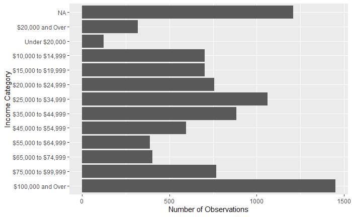

```r
# create a bar graph showing income category

ggplot(nhanes.2012.clean, aes(x = factor(income, levels = c(
                              "$100,000 and Over",
                              "$75,000 to $99,999",
                              "$65,000 to $74,999",
                              "$55,000 to $64,999",
                              "$45,000 to $54,999",
                              "$35,000 to $44,999",
                              "$25,000 to $34,999",
                              "$20,000 to $24,999",
                              "$15,000 to $19,999",
                              "$10,000 to $14,999",
                              "$5,000 to $9,999",
                              "$0 to $4,999",
                              "Under $20,000",
                              "$20,000 and Over")))) +
  geom_bar(na.rm = TRUE) +
  coord_flip() +
  xlab("Income Category") +
  ylab("Number of Observations")
```

### This plot shows that the average salary is most likely around $45,000. Due to the unexpectedly high number of reported salaries above $100,000, there is most likely either a response bias where people are more likely to answer this question if they have a higher salary, or people were not reporting their salaries honestly.

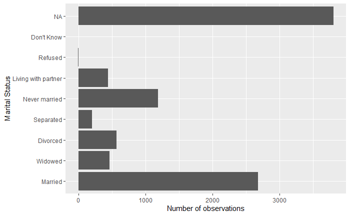

```r
ggplot(nhanes.2012.clean, aes(x=marital)) +
  geom_bar() +
  coord_flip() +
  xlab("Marital Status") +
  ylab("Number of observations")
```

### This plot shows that the most frequent category is the Married category with Never married coming in second. The third most frequent marital status is the Divorced category.

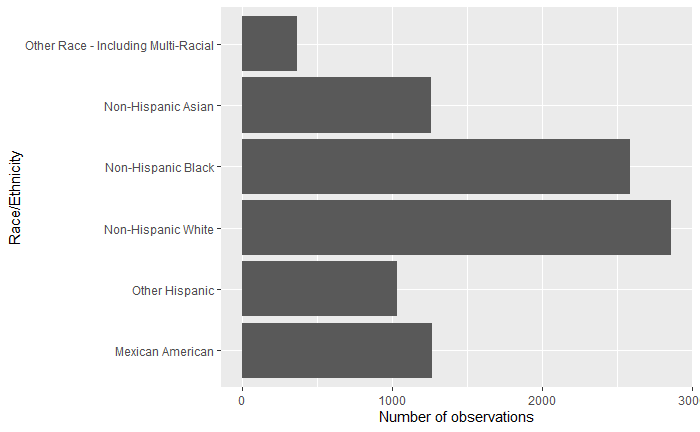

```r
ggplot(nhanes.2012.clean, aes(x=race.eth)) +
  geom_bar() +
  coord_flip() +
  xlab("Race/Ethnicity") +
  ylab("Number of observations")
```

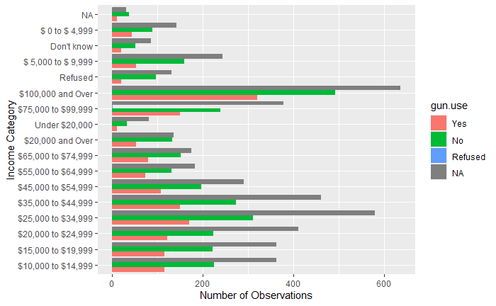

```r
ggplot(nhanes.2012.clean, aes(x = income, fill=gun.use)) +
  geom_bar(position = "dodge") +
  coord_flip() +
  xlab("Income Category") +
  ylab("Number of Observations")
```

### Adding the fill layer allows us to see the responses colored by the person’s answer to the gun use question. The majority of people answered “No” to gun use in each income category. The income category with the highest occurrence of gun use is the $100,000 and over category with approximately 300 observations.

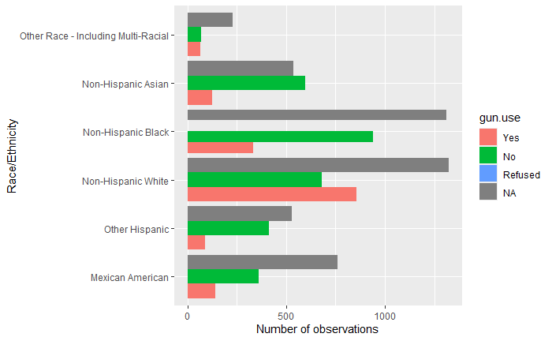

```r
ggplot(nhanes.2012.clean, aes(x=race.eth, fill=gun.use)) +
  geom_bar(position="dodge") +
  coord_flip() +
  xlab("Race/Ethnicity") +
  ylab("Number of observations")
```

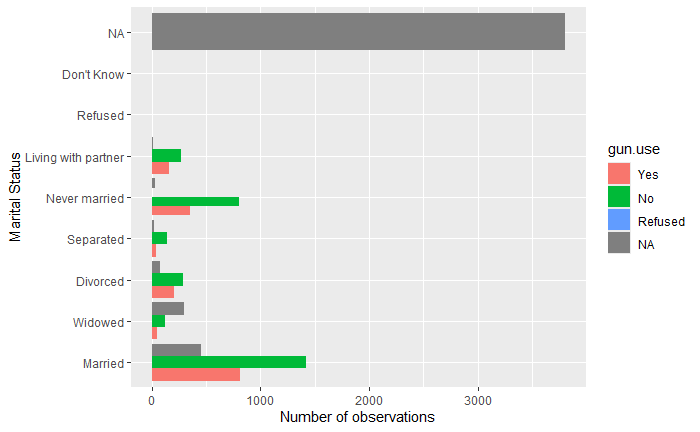

```r
ggplot(nhanes.2012.clean, aes(x=marital, fill=gun.use)) +
  geom_bar(position="dodge") +
  coord_flip() +
  xlab("Marital Status") +
  ylab("Number of observations")
```

### From this graph, it appears that gun use stays relatively the same in all marital status categories. For each category, there are more observations of people who did not use guns than people who did use guns.